# Load Data

```python
import pandas as pd

df_Social_Mentions = pd.read_csv('https://storage.googleapis.com/datalynn-datasets/interview-challenge/finance/Paypal_Sentiment_Analysis/SocialMentions.csv')
df_Social_Mentions.head()
```

|  | user_id | platform | mention | timestamp | followers | region | sentiment |
| --- | --- | --- | --- | --- | --- | --- | --- |
| 0 | user_0 | Reddit | Had a problem with PayPal.again | 2023-08-28 18:48:00 | 784 | Asia | Negative |
| 1 | user_1 | Instagram | My PayPal transaction had issues. | 2023-08-26 18:48:00 | 4691 | North America | Negative |
| 2 | user_2 | Facebook | My PayPal transaction had issues. | 2023-07-31 18:48:00 | 4596 | North America | Negative |
| 3 | user_3 | Reddit | Paypal is good.today | 2023-08-31 18:48:00 | 113 | South America | Negative |
| 4 | user_4 | Twitter | Paypal is good.today | 2023-09-03 18:48:00 | 3198 | Europe | Negative |

```python
df = df_Social_Mentions.copy()
```

## Question 1

**Sentiment Distribution Analysis:**  
Given the `Social_Mentions` data from the past year, can you explore the distribution of sentiments across various platforms? While analyzing, ensure to highlight any anomalies or surprising patterns, possibly indicating emerging issues or trends.

**Analysis of Sentiment Distribution**

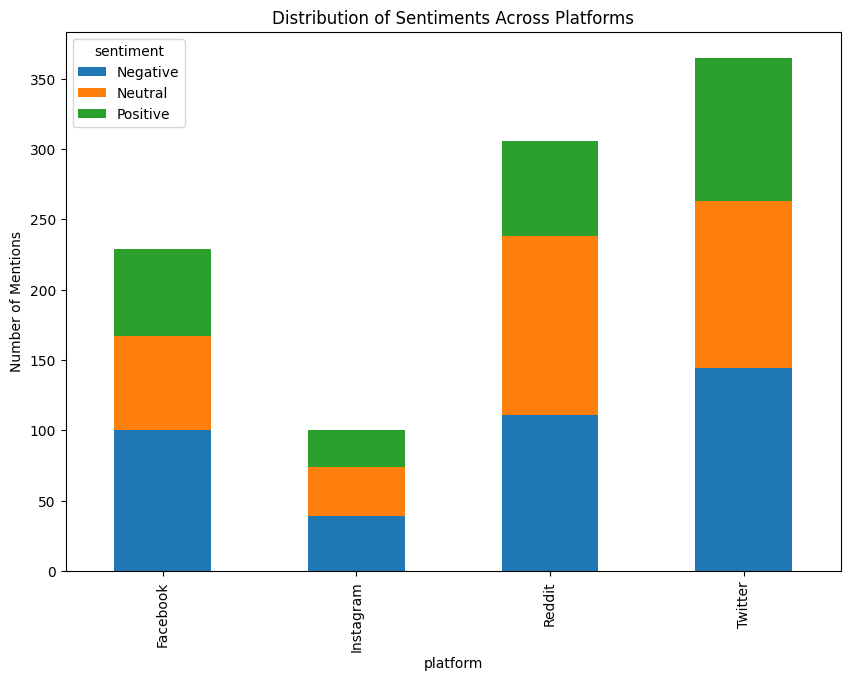

```python
import nltk
import matplotlib.pyplot as plt
import seaborn as sns

# Group by platform and sentiment, then count the mentions
sentiment_dist = df.groupby(['platform', 'sentiment']).size().unstack().fillna(0)

# Plotting
sentiment_dist.plot(kind='bar', stacked=True, figsize=(10, 7))
plt.title('Distribution of Sentiments Across Platforms')
plt.ylabel('Number of Mentions')
plt.show()
```

**Highlight Patterns**

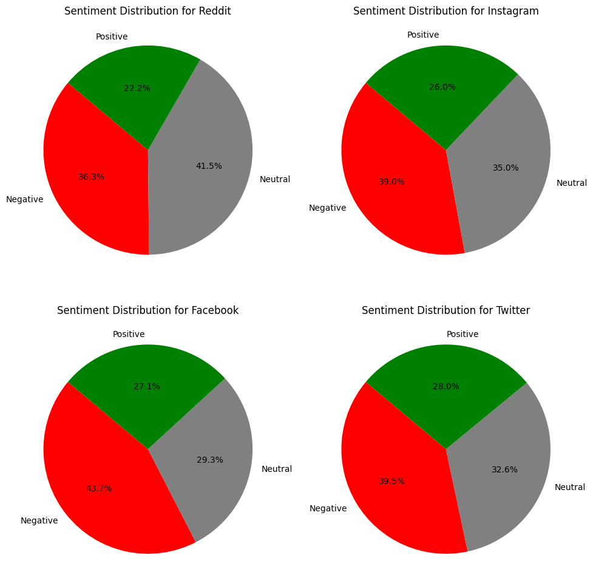

```python
# First, compute the total mentions for each platform
platform_totals = df.groupby('platform').size()

# Next, get the count of each sentiment for each platform
sentiment_counts = df.groupby(['platform', 'sentiment']).size().unstack().fillna(0)

# Compute the percentage
sentiment_percentage = (sentiment_counts.divide(platform_totals, axis=0) * 100).round(2)

fig, axs = plt.subplots(2, 2, figsize=(10, 10))  # 2x2 grid for 4 platforms
axs = axs.ravel()  # Flatten the grid to make indexing easier

# Iterate through each platform to plot pie charts
platforms = df['platform'].unique()

for i, platform in enumerate(platforms):
    subset = sentiment_percentage.loc[platform]
    axs[i].pie(subset, labels=subset.index, autopct='%1.1f%%', startangle=140, colors=['red', 'grey', 'green'])  # colors corresponding to negative, neutral, positive
    axs[i].set_title(f'Sentiment Distribution for {platform}')

plt.tight_layout()
plt.show()
```

From the pie chart we created, we can identify that on all platforms, the percentage of negative reviews is higher than the percentage of positive reviews. In terms of the positives, twitter has the highest percentage.

## Question 2

**Identify Influential Users with Negative Sentiments:**  
An influential user's negative sentiment can significantly impact brand perception. By taking into consideration the `followers` column, create an algorithm to identify and rank users based on their influence and the negativity of their `mention`.

In this case, we first map the sentiment to scores. Let's assign `-1` for negative sentiment, `0` for neutral, and `1` for positive. Then we define the influential score as `followers` * `sentiment_score`.

```python
# Convert sentiment into numerical score
def sentiment_score(sentiment):
    if sentiment == "Negative":
        return -1
    elif sentiment == "Neutral":
        return 0
    else:  # positive
        return 1

df['sentiment_score'] = df['sentiment'].apply(sentiment_score)

# Compute influence score
df['influence_score'] = df['sentiment_score'] * df['followers']

# Filter for only negative sentiments to focus on those that can harm brand perception
negative_influencers = df[df['sentiment'] == 'Negative']

# Rank users based on their influence score
ranked_users = negative_influencers.sort_values(by='influence_score', ascending=True)

ranked_users[['user_id', 'influence_score']].head()
```

|  | user_id | influence_score |
| --- | --- | --- |
| 318 | user_318 | -11389 |
| 61 | user_61 | -11337 |
| 539 | user_539 | -10849 |
| 5 | user_5 | -10571 |
| 79 | user_79 | -10279 |

## Question 3

**Predictive Modeling for Sentiment Analysis:**  
Develop a predictive model to classify the sentiment of a `mention` as Positive, Neutral, or Negative. For this, treat the sentiment as the target variable. How would you ensure that this model is not overfitting and is generalizable across different regions?

- *Target Variable: Sentiment (Positive, Neutral, Negative)*

```python
from sklearn.model_selection import train_test_split
from sklearn.feature_extraction.text import TfidfVectorizer
from sklearn.linear_model import LogisticRegression
from sklearn.metrics import classification_report

# Preprocessing: Vectorization using TF-IDF
tfidf = TfidfVectorizer(stop_words='english', max_features=500)
X = tfidf.fit_transform(df['mention'])
y = df['sentiment']

# Splitting the data
X_train, X_valid, y_train, y_valid = train_test_split(X, y, test_size=0.2, random_state=42, stratify=y)

# Training a Logistic Regression model
clf = LogisticRegression(max_iter=100)
clf.fit(X_train, y_train)

# Predicting and evaluating
y_pred = clf.predict(X_valid)
print(classification_report(y_valid, y_pred))
```

```
              precision    recall  f1-score   support

    Negative       0.86      1.00      0.92        79
     Neutral       1.00      1.00      1.00        70
    Positive       1.00      0.75      0.85        51

    accuracy                           0.94       200
   macro avg       0.95      0.92      0.93       200
weighted avg       0.94      0.94      0.93       200
```

**Methods to ensure the model is not overfitting and generalizable:**

- **Splitting Data:** Divide the data into training and test (and possibly validation) sets. This allows the model to be evaluated on unseen data.
- **Cross-Validation:** You can implement k-fold cross-validation, especially if the dataset isn't huge.
- **Stratified Sampling:** When splitting data, it's crucial to maintain the distribution of the target class (sentiment in this case) and other important categorical variables (like regions). This ensures that the model is trained evenly across all classes and regions.

## Question 4

**Impact of Region on Sentiment:**  
We are considering a new marketing campaign tailored to specific regions. Can you help identify if certain regions have a higher propensity for negative sentiments compared to others? Use statistical tests to confirm any observed differences.

```python
from scipy.stats import chi2_contingency

# Assuming df_Social_Mentions is the dataframe from previous steps

# Create a contingency table
contingency = pd.crosstab(df['region'], df['sentiment'])

print("Contingency Table:")
print(contingency)

# Apply the chi-square test
chi2, p, _, expected = chi2_contingency(contingency)

print("\nChi-Square Value =", chi2)
print("P-value =", p)
print("\nExpected Table:")
print(pd.DataFrame(expected, columns=contingency.columns, index=contingency.index))

# Check the significance
alpha = 0.05
if p < alpha:
    print("\nThe association between region and sentiment is statistically significant.")
else:
    print("\nThere's no statistically significant association between region and sentiment.")
```

```
Contingency Table:
sentiment      Negative  Neutral  Positive
region
Africa               38       46        16
Asia                102       95        60
Australia            21       13         7
Europe               74       69        62
North America       120      102        81
South America        39       23        32

Chi-Square Value = 18.998924652181877
P-value = 0.04027634301561772

Expected Table:
sentiment      Negative  Neutral  Positive
region
Africa           39.400   34.800    25.800
Asia            101.258   89.436    66.306
Australia        16.154   14.268    10.578
Europe           80.770   71.340    52.890
North America   119.382  105.444    78.174
South America    37.036   32.712    24.252

The association between region and sentiment is statistically significant.
```

```python
import numpy as np

# Calculate standardized residuals
residuals = (contingency - expected) / np.sqrt(expected)

print("Standardized Residuals Table:")
print(residuals)

# Identify significant residuals for negative sentiment
most_significant_region = residuals['Negative'].abs().idxmax()

print("\nRegions with significantly different negative sentiment counts:")
print(most_significant_region)
```

```
Standardized Residuals Table:
sentiment      Negative   Neutral  Positive
region
Africa        -0.223039  1.898578 -1.929373
Asia           0.073738  0.588343 -0.774422
Australia      1.205711 -0.335689 -1.100116
Europe        -0.753292 -0.277044  1.252655
North America  0.056561 -0.335392  0.319625
South America  0.322723 -1.698068  1.573316

Regions with significantly different negative sentiment counts:
Australia
```